# Introduction to *cellcount*

T.E. Harman, M. Vandersea, D.E. Berthold, H.D. Laughinghouse, B. Boyd, K. Pokrzywinski

02/27/2023

Abstract

The *cellcount* package provides wrapper functions for [*EBImage*](http://bioconductor.org/packages/devel/bioc/vignettes/EBImage/inst/doc/EBImage-introduction.html) to simplfy quantifying bacteria and cyanobacteria via flourescence microscopy. Cyanobacteria enumeration is an important tool to incorporate data results into mathematical models to assess bloom dynamics. However, standard manual cyanobacteria enumeration is considered time-consuming and can impact overall random error due to different inaccuracies from researcher to researcher. Here, we outline a new open-source tool, *cellcount*, a package designed for the computing language R to assist with cyanobacteria enumeration. Fluorescent microscopy images are analyzed by this package to generate cyanobacteria counts to assess overall cell density from samples.

# Overview:

Climate change and anthropogenic impacts have exacerbated the presence of harmful algal blooms (HABs) within marine and freshwater environments. Rising temperatures, stratification strength, reduction of vertical mixing, and increases in nutrients attribute to these increases in blooms. Routine monitoring of HABs has become important in order to understand ecosystem and public health risk and establish mitigation practices.

Standard methods involve the enumeration of HAB species using microscopy methods (i.e. hemocytometer), which is considered the gold standard, as well as other methods such as qPCR and flow cytometry. These methods can be time consuming and require significant knowledge related to these technologies. Technology has advanced enumeration needs to decrease time consumption while also maintaining accuracy. Instruments such as the FlowCam™ and Imaging Flow Cytobot (IFCB) have been developed for these purposes; however, these instruments are expensive to purchase, operate, and maintain. The need for open-source technologies is important for accessibility reasons, but also for end-user customization needs.

Our project sought to solve the two mentioned issues on developing enumeration technology for open-source capabilities: accessibility and customization. A prior report released by Pokrzywinski et al. (2019) had outlined the development of an automated cyanobacteria enumeration script using the open-source programming language, R, along with several functions from the R package *EBImage*. However, the previous presentation of this script can be considered extremely difficult to grasp for inexperienced R users. We utilized this script as a template for the development of an R package, involving the reduction of code into simple functions, expanding the ability for end-user modifications, development of a vignette for inexperienced users, and promoting open-source availability. Along with these goals, we aim to establish a rapid and accurate enumeration method for researchers, where significantly less time is consumed compared to the standard enumeration methods available.

# Getting started:

The following packages are required. Please install and bring them into the R environment:

```r
if (!requireNamespace("BiocManager", quietly = TRUE)) {
  install.packages("BiocManager")
}
if (!require("EBImage")) {
  BiocManager::install("EBImage")
}
library(EBImage)
library(tiff)
library(pixmap)
library(raster)
```

# Setting up directories/reading files:

To begin, we generate a data frame for the proceeding count data to be added into using the following code:

```r
Cell.Count <- data.frame(Image_File_Name = character(0), Cell_Count = numeric(0))
```

Next, end-users will need to generate a couple of directories; one for saving the unique color label images and another for CSV files. In this example, we are using images of *Microcystis* sp. cells that are contained within the package as test data. Please note that your directory addresses will be different. We recommend using a dedicated directory for *cellcount* results:

```r
savdir <- ("file path for saving CSV data")
image_savdir <- ("file path for saving converted images")
```

Next, end-users will need to read in the images you are interested in processing using the following code. Once again, your directories will be different and must be updated to the correct file address. However, in this example we will be using the provided test images from this package:

```r
images <- list.files("file path of images to analyze", pattern = "tif", full.name = T)
images_names <- list.files("file path of images to analyze", pattern = "tif", full.name = F)
```

In addition, end-users will need to assign the file names to a vector; this provides characterization to each file for easy organization:

```r
file_name<-paste0("F192_")
```

Now we will “read” in the images that we are interested in analyzing. The following code outlines this step using the “*readTIFF*” function from the *tiff* package. In addition, we’ll need to re-orient the image as it’s uploaded into the environment. The “*readTIFF*” function uploads images in a portrait format - the “*aperm*” function reorients the uploaded image to a landscape format:

```r
imgNames <- paste0(file_name, images_names)
read_images <- lapply(images, readTIFF)
img_transposed <- lapply(read_images,aperm,c(2,1,3))
names(images) <- imgNames
```

# Beginning the conversion process:

Now that our images are within the R environment, we can begin to convert these images into useful data that R can use to process images. First, we begin by converting 24-bit images into 8-bit images using the “*greyscale*” function (see photo below). This function also has a built-in numerical contrast adjustment that end-users can adjust:

```r
greyscale <- function(x, contrast = 2) {
  x <- contrast * x
  x <- x[, , 1] + x[, , 2] + x[, , 3]
  x <- x / max(x)
  x <- normalize(x, inputRange = c(0.1, 0.75))
  return(x)
}
```

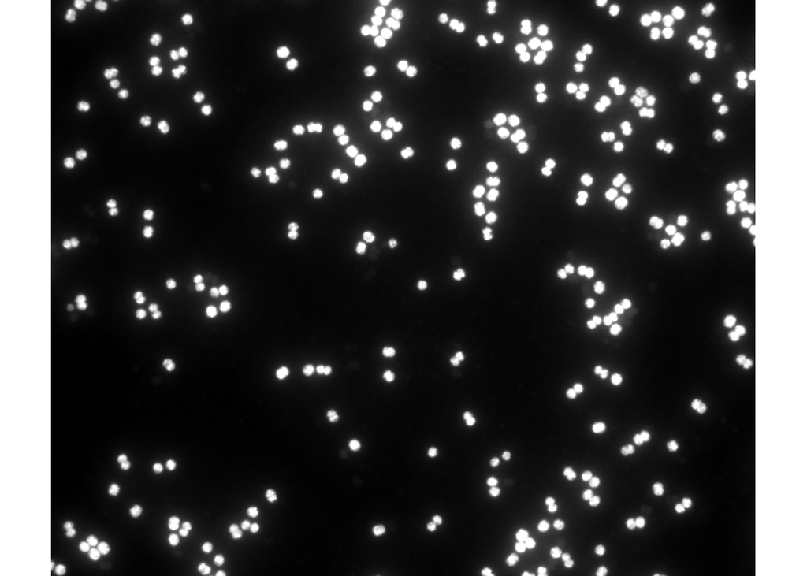

```r
grey_images <- lapply(img_transposed, greyscale, contrast = 1)
display(grey_images[[5]])
```

Next, we will use the “*mapped*” function to turn the 8-bit image we just converted into a data matrix (using “*as.matrix*”) using the following code. This also includes a pixel intensity threshold adjustment that end-users can change; this removes any pixel that is under the threshold value to easily separate the background from cells:

```r
mapped <- function(x, threshold = 0.3) {
  x <- as.matrix(x)
  x[x < threshold] <- 0
  return(x)
}
```

```r
imagesMapped <- lapply(grey_images, mapped, threshold = 0.3)
```

Before we analyze our images in bulk, we introduce here several functions that are required to take matrix data to count cells within images and to produce “*color-label*” images. These include the following:

**“*countImages*” function:** Displays converted microscopy images of distinct cell counts subsequently from the “*image_convert function*”. End-users can use the “*display*” function from *EBImage* to visually generate the produced image from this function.

```r
countImages <- function(image, normalize = TRUE, removeEdgeCells = TRUE) {
  if (removeEdgeCells) {
    dims <- dim(image)
    border1 <- border(image, dims)
    ids <- unique(border1[which(border1 != 0)])
    inner <- rmObjects(image, ids)
    EBImage::colorLabels(inner, normalize = normalize)
  } else {
    EBImage::colorLabels(image, normalize = normalize)
  }
}
```

**“*border*” function:** Takes images to predict cells along a predetermined border in order to count cells within the predetermined border. Cells along the predetermined border are not counted, which is outlined in the “*countCells*” function.

```r
border <- function(x, y) {
  c(x[1:y[1], 1], x[1:y[1], y[2]], x[1, 1:y[2]], x[y[1], 1:y[2]])
}
```

**“*countCells*” function:** Takes information from a converted image and counts cells within the image. This uses the “*border*” function to remove cells along the image border and only count cells within the image.

```r
countCells <- function(x) {
  countAll <- max(x)
  dims <- dim(x)
  border1 <- border(x, dims)
  ids <- unique(border1[which(border1 != 0)])
  countInner <- countAll - length(ids)
  return(countInner)
}
```

**“*image_convert*” function:** Takes a mapped image (i.e., data matrix) and counts individual cells within an image. This is to be used with a single image with cells that contains a single fluorescent dimension (i.e. auto-fluorescence, DAPI, etc.). This is useful for analyzing images containing single-cell cyanobacteria.

```r
image_convert <- function(x, w = 17, h = 17, offset = 0.001, areathresh = 50, tolerance= 0.5, ext = 1) {
  image <- thresh(x, w = w, h = h, offset = offset)
  image1 <- fillHull(image)
  image2 <- watershed(distmap(image1), tolerance = tolerance, ext = ext)
  nf <- computeFeatures.shape(image2)
  nr <- which(nf[, "s.area"] < areathresh)
  image3 <- rmObjects(image2, nr)
  return(image3)
}
```

We also include a separate, yet similar function to “*image_convert*” called “*image_convert2*”. This function is ideally meant for filamentous or colonial-type cyanobacteria that are harder to discern with the standard “*image_convert*” function. The difference between these functions are that the “*watershed*” function from the *EBImage* package comes first in the outlined function compared to the “*image_convert*” function.

```r
image_convert2 <- function(x, w = 17, h = 17, offset = 0.001, areathresh = 50, tolerance= 0.5, ext = 1) {
  image <- thresh(x, w = w, h = h, offset = offset)
  image1 <- watershed(distmap(image), tolerance = tolerance, ext = ext)
  image2 <- fillHull(image1)
  nf <- computeFeatures.shape(image2)
  nr <- which(nf[, "s.area"] < areathresh)
  image3 <- rmObjects(image2, nr)
  return(image3)
}
```

In addition, set aside some code space to visually analyze image results. This could include adjusting the threshold from the “*mapped*” function, the contrast from the “*greyscale*” function (if used), or could involve making adjustments to the “*image_convert*” function, such as the width and height of the rectangular window, the pixel area threshold (i.e., removes cells or other objects under a certain pixel area), or the tolerance and ‘ext’ variables. Observe the initial results as indicated below and make adjustments where necessary:

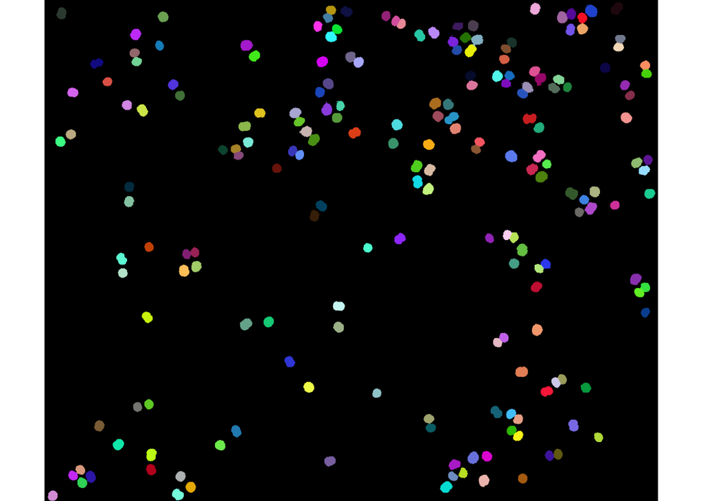

```r
imagesConverted <- image_convert(imagesMapped[[5]], w = 10, h = 10, offset = 0.001, areathresh = 250,
                                 tolerance = 0.8, ext = 1)
final_img <- countImages(imagesConverted, normalize = T, removeEdgeCells = T)
display(final_img)
```

# Analysis of images for producing count data:

Once end-users have made necessary adjustments, use the following for-loop to analyze images in bulk from a directory, yet one at a time. The for-loop uses the “*image_convert*” function to produce unique color labels on cells within an image and to produce a final image showcasing these labels using the “*countImages*” function. Finally, “*countCells*” is used to count the number of unique color labels (i.e., cells). We also have integrated code to add these count results to the data frame made earlier, and also to save each unique color label image to the “image_savdir” directory:

```r
for (z in 1:length(images)) {
  imagesConverted <- image_convert(imagesMapped[[z]], w = 10, h = 10, offset = 0.001, areathresh = 250,
                                   tolerance = 0.8, ext = 1)
  final_img <- countImages(imagesConverted, normalize = T, removeEdgeCells = T)
  count <- countCells(imagesConverted)
  Cell.Count[nrow(Cell.Count) + 1, ] <- c(imgNames[[z]], count)
  analyzed_image <- paste0(sub(".tif", replacement = "", x = imgNames[z]), "_analyzed.tiff")
  writeImage(final_img, files = paste0(image_savdir, analyzed_image),compression=c("LZW"))
}
```

Data from the image analysis has been generated in our data frame “Cell.Count” that we previously made. We can use the following code to view the current results:

```r
Cell.Count
```

```
##                 Image_File_Name Cell_Count
## 1  F192_Microcystis_Demo_01.tif        207
## 2  F192_Microcystis_Demo_02.tif        183
## 3  F192_Microcystis_Demo_03.tif        238
## 4  F192_Microcystis_Demo_04.tif        219
## 5  F192_Microcystis_Demo_05.tif        196
## 6  F192_Microcystis_Demo_06.tif        216
## 7  F192_Microcystis_Demo_07.tif        206
## 8  F192_Microcystis_Demo_08.tif        223
## 9  F192_Microcystis_Demo_09.tif        216
## 10 F192_Microcystis_Demo_10.tif        229
```

Some images that were initially taken may be too poor of quality or contain high background fluorescence, among other errors. The code below analyzes outliers from the produced data, within a range of two standard deviations above and below the median. The “*outlier*” function tags which images are out of this range and dictates a warning within our data frame, “Cell.Count”, which is shown below. This function’s primary objective is to alert end-users of potential imaging/processing issues. This alerts the end-user to perhaps re-image a particular sample, or to investigate the error further, if any.

```r
outlier<-function(){
  mean<-median(Cell.Count$Cell_Count)
  sd<-sd(Cell.Count$Cell_Count)*2
  sd_neg<-(mean-sd)
  sd_pos<-(mean+sd)
  SD_range_detection<-ifelse(sd_pos>Cell.Count$Cell_Count,Cell.Count$Cell_Count,NA)&
    ifelse(sd_neg<Cell.Count$Cell_Count,Cell.Count$Cell_Count,NA)
  return(SD_range_detection)
}
```

```r
Cell.Count$Cell_Count<-as.numeric(Cell.Count$Cell_Count)
Cell.Count$SD_range<-outlier()
Cell.Count
```

```
##                 Image_File_Name Cell_Count SD_range
## 1  F192_Microcystis_Demo_01.tif        207     TRUE
## 2  F192_Microcystis_Demo_02.tif        183       NA
## 3  F192_Microcystis_Demo_03.tif        238     TRUE
## 4  F192_Microcystis_Demo_04.tif        219     TRUE
## 5  F192_Microcystis_Demo_05.tif        196     TRUE
## 6  F192_Microcystis_Demo_06.tif        216     TRUE
## 7  F192_Microcystis_Demo_07.tif        206     TRUE
## 8  F192_Microcystis_Demo_08.tif        223     TRUE
## 9  F192_Microcystis_Demo_09.tif        216     TRUE
## 10 F192_Microcystis_Demo_10.tif        229     TRUE
```

In order to calculate cell density of these images, we can use the “*cell.density*” function that’s built into the *cellcount* package. We first need to generate the total amount of cells counted from these images and add it to our existing data frame using the following code:

```r
cell.total <- as.numeric(Cell.Count$Cell_Count)
cell.total <- sum(cell.total)
Cell.Count[nrow(Cell.Count) + 1, ] <- c("Cell Total", cell.total,"null")
```

*Important note* - *the “null” data produced in the code above (and others that* *follow) fills in the blanks from the previous data produced by the* *“outlier” function.*

Calculating cell density, taken from Wetzel and Likens 1991, requires multiple values. End-users will need the following information to precisely calculate this value:

- Total counts (generated previously)
- Height of image field of view (μm)
- Width of image field of view (μm)
- Total number of images analyzed
- Filtration area (mm<sup>2</sup>)
- Volume filtered per image (mL)
- Total sample volume (mL)

Field of view (FOV - mm<sup>2</sup>) is an important variable calculated from image height and image width. Image height and width are variables that are taken from dimensions disseminated by the microscope camera’s manufacturer. End-users must refer to their camera documentation to calculate the FOV variable correctly.

With the variables calculated, the following “*cell_density*” uses these variables to calculate cell density and adds the data into the “Cell.Count” data frame:

```r
cell_density <- function(x, FOV = 0.0726, images = 10, filtration.area = 213.8,
                         volume = 1, total.volume = 5) {
  MCF <- filtration.area / FOV
  N <- x / images
  cyano <- (MCF * N) / volume
  cyano_total <- cyano * total.volume
  return(cyano_total)
}
```

```r
cell.den <- cell_density(cell.total, FOV = 0.0726, images = 10, filtration.area = 213.8,
                         volume = 1, total.volume = 5)
Cell.Count[nrow(Cell.Count) + 1, ] <- c("Cell Density", cell.den,"null")
```

We can also calculate the average number of cells per image, as well as cells per mL using the following code. Note that ‘cell.av’ must be divided by the number of images the end-user has analyzed, and the ‘cell.mL’ must be divided by the total volume from the original sample:

```r
cell.av<-(cell.total/10) #change this via total number of images
Cell.Count[nrow(Cell.Count) + 1, ] <- c("Imaging Average",cell.av,"null")

cell.mL<-(cell.den/5) #change this via total volume
Cell.Count[nrow(Cell.Count) + 1, ] <- c("Total Volume Cell per mL",cell.mL,"null")
```

We can now view our data frame to double check for any calculation errors:

```r
Cell.Count
```

```
##                 Image_File_Name       Cell_Count SD_range
## 1  F192_Microcystis_Demo_01.tif              207     TRUE
## 2  F192_Microcystis_Demo_02.tif              183     <NA>
## 3  F192_Microcystis_Demo_03.tif              238     TRUE
## 4  F192_Microcystis_Demo_04.tif              219     TRUE
## 5  F192_Microcystis_Demo_05.tif              196     TRUE
## 6  F192_Microcystis_Demo_06.tif              216     TRUE
## 7  F192_Microcystis_Demo_07.tif              206     TRUE
## 8  F192_Microcystis_Demo_08.tif              223     TRUE
## 9  F192_Microcystis_Demo_09.tif              216     TRUE
## 10 F192_Microcystis_Demo_10.tif              229     TRUE
## 11                   Cell Total             2133     null
## 12                 Cell Density 3140739.66942149     null
## 13              Imaging Average            213.3     null
## 14     Total Volume Cell per mL 628147.933884298     null
```

Finally, we write the following code to export our finalized .csv file to our pre-determined save directory:

```r
write.csv(Cell.Count, paste0(savdir, "/F192_Test counts.csv"))
```